# NYC Rent Explorer Vignette

Joshua V. O’Steen, Christopher Hoffman, Yashar Mansouri

5/2/2021

NYC Rent Explorer is a shiny application that utilizes New York City renting data in order to analyze rent pricing trends. It examines how the cost of different apartment types and areas of NYC have changed over time.

This is a multi-purpose app which can provide useful market information to renters, landlords, economists and researchers.

The github repository can be found [here](https://github.com/STAT-413-613-21S/fp_final-project-cjy)

## Map and Time Series Analysis

The first tab allows the user to select a NYC borough (Manhattan, Brooklyn, Queens, Bronx) and a neighborhood corresponding to the chosen borough.

Once the user has done that, the map will automatically update, showing the physical location of the neighborhood in NYC. Below the map, a time series chart displays how the median rent of the selected neighborhood and apartment type (default studio) has changed over time.

The user has the option to view the median price time series for different apartment types by using the “Select an apartment type” drop-down menu.

## Data Spreadsheet

The final tab of NYC Rent Explorer is simply master data spreadsheet that is used in order to create the charts and data analysis of the previous sections.

The data will automatically filter and update based on user input. If the user wants to look at the raw data for Woodside, Queens, they simply type in the neighborhood and borough name:

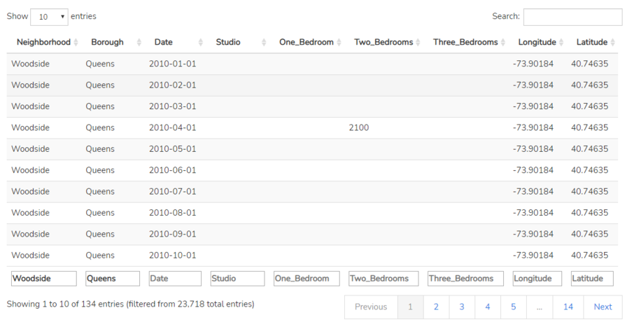

## Required Packages

NYC Rent Explorer utilizes various R packages. A short description and link to their respective package websites are referenced below:

- [shiny](https://cran.r-project.org/web/packages/leaflet/index.html): Used to create this application
- [rgdal](https://cran.r-project.org/web/packages/rgdal/index.html): Provides spatial information for interactive, leaflet map
- [leaflet](https://cran.r-project.org/web/packages/leaflet/index.html): Create dynamic map that shows the neighborhood of NYC
- [plotly](https://cran.r-project.org/web/packages/plotly/index.html): Create more powerful, interactive maps
- [dygraphs](https://cran.r-project.org/web/packages/dygraphs/index.html): Useful library to enhance time series graphics
- [prophet](https://cran.r-project.org/web/packages/prophet/index.html): Library revolving around time series work, used in our time series forcast tab
- [shinythemes](https://cran.r-project.org/web/packages/shinythemes/index.html): Used to create a sleeker visual design for our shiny application
- [tidyverse](https://www.tidyverse.org/packages/): Useful collection of libraries; mainly used for data cleaning in EDA in our case

## Data Source and Structure

Our data is structured so that each observation (row) stores the neighborhood name, borough name, a date (which is the first day of every month since 2010 till 2021), median rent price for a studio, one bedroom, two bedroom, three bedroom+, and the longitude and latitude coordinates of the neighborhood.

NYC Rent Explorer sources its data from [StreetEasy.com](https://streeteasy.com/blog/download-data/), which is an online real estate marketplace that exclusively operations in New York City.

NYC Rent Explorer is in no way related nor sponsored with [StreetEasy.com](https://streeteasy.com/blog/download-data/)